# k-Nearest Neighbours

## Choosing the best k

Testing the missclassification rate for different values of k.

```r
kmax <- 50
k <- 1:kmax
p <- rep(0, kmax)
ntest <- nrow(test)

k_summary <- cbind(k, p)
colnames(k_summary) <- c("k", "% misclassified")

for (i in 1:kmax) {
  result <- knn(train, test, cl = simT[train_ind, 3], k = i)
  table <- table(result, simT[test_ind, 3])
  sum_agree <- sum(diag(table))
  k_summary[i, 2] <- (ntest - sum_agree) / ntest
}

k_summary[1:10, ]
```

```
##        k % misclassified
##  [1,]  1           0.164
##  [2,]  2           0.178
##  [3,]  3           0.164
##  [4,]  4           0.178
##  [5,]  5           0.156
##  [6,]  6           0.160
##  [7,]  7           0.164
##  [8,]  8           0.164
##  [9,]  9           0.158
## [10,] 10           0.154
```

We can plot the the results:

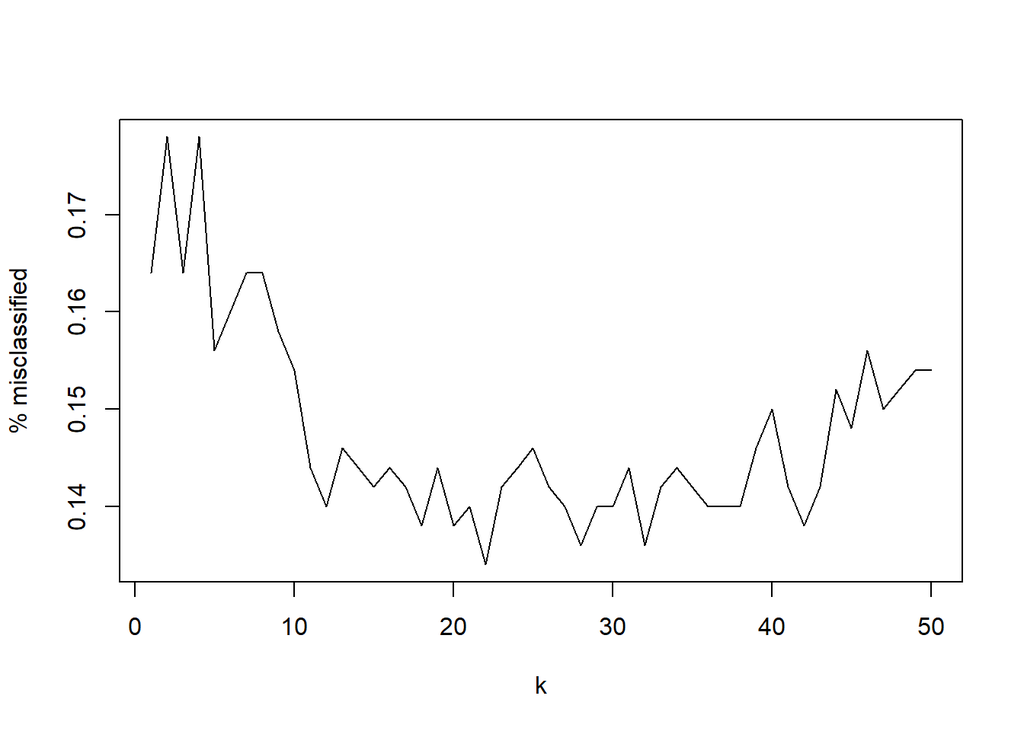

```r
plot(k_summary[, 1], k_summary[, 2], type = "l", xlab = "k", ylab = "% misclassified")
```

Pick the lowest value of k that gives the lowest misclassification rate. We can use `which.min` which returns the index of the first occurrence of the minimum value in a vector.

```r
min_k <- which.min(k_summary[, 2])
print(paste("Best k: ", min_k))
```

```
## [1] "Best k:  22"
```

## Validation

Now we can use the best $k$ to classify the validation set to estimate the classification error.

```r
val_pred <- knn(train, val, cl = simT[train_ind, 3], k = min_k)
table <- table(val_pred, simT[val_ind, 3])
error <- 1 - sum(diag(table)) / sum(table)
print(paste("Validation error: ", error))
```

```
## [1] "Validation error:  0.15"
```

We can plot how the model performs on the validation set.

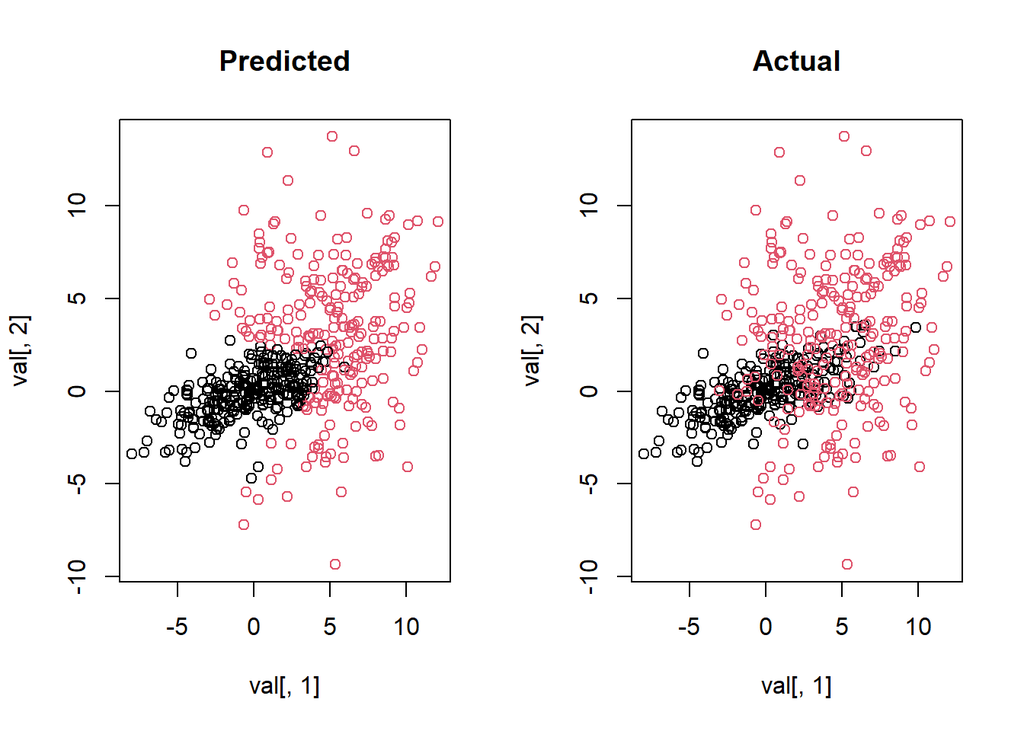

```r
par(mfrow = c(1, 2))
plot(val[, 1], val[, 2], col = val_pred, main = "Predicted")
plot(val[, 1], val[, 2], col = simT[val_ind, 3], main = "Actual")
```

## Choosing the best k using cross-validation

We can use cross-validation to choose the best value of $k$. Let’s use 10-fold cross-validation.

```r
# split the data into 10 folds
folds <- cut(1:1000, breaks = 10, labels = FALSE)
folds <- rep(folds, 2)

kmax <- 50
k <- 1:kmax
p <- rep(0, kmax)

k_summary <- cbind(k, p)
colnames(k_summary) <- c("k", "% misclassified")

for (i in 1:kmax) {
  proportion_classified <- 0
  for (j in 1:10) {
    train_ind <- which(folds != j) # train on all folds except the j-th fold
    test_ind <- which(folds == j) # test on the j-th fold

    result <- knn(train = simT[train_ind, -3], simT[test_ind, -3], cl = simT[train_ind, 3], k = i)
    table <- table(result, simT[test_ind, 3])
    proportion_classified <- proportion_classified + sum(diag(table)) / sum(table)
  }
  k_summary[i, 2] <- 1 - proportion_classified / 10
}

k_summary[1:10, ]
```

```
##        k % misclassified
##  [1,]  1          0.1795
##  [2,]  2          0.1895
##  [3,]  3          0.1695
##  [4,]  4          0.1635
##  [5,]  5          0.1640
##  [6,]  6          0.1695
##  [7,]  7          0.1605
##  [8,]  8          0.1550
##  [9,]  9          0.1580
## [10,] 10          0.1530
```

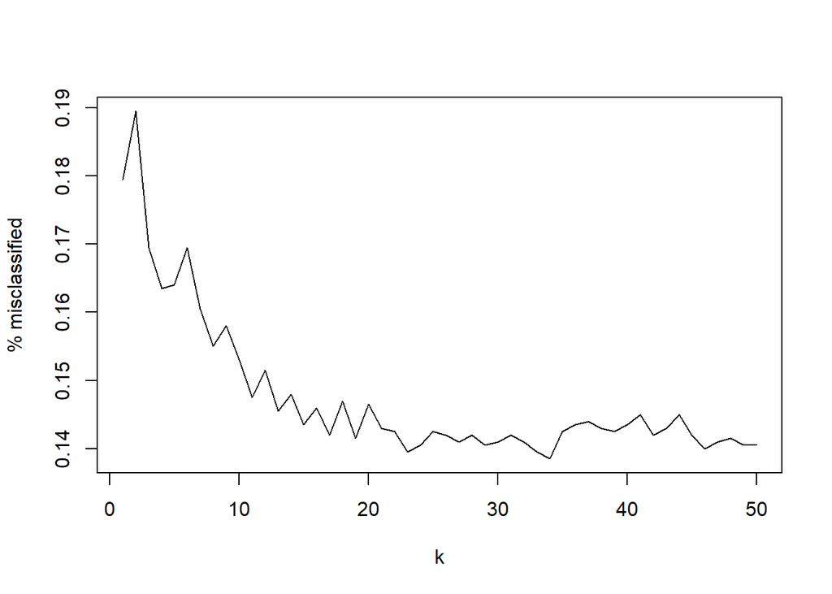

```r
plot(k_summary[, 1], k_summary[, 2], type = "l", xlab = "k", ylab = "% misclassified")
```

```r
min_k <- which.min(k_summary[, 2])
print(paste("Best k: ", min_k))
```

```
## [1] "Best k:  34"
```